# Eflows Species Clustering in CA Regions

## Overview and Basic Methods

In this version (June 2018) of the clustering, all primary species types were included - current range, historical range, and translocated range. All HUCs were included, regardless of the minimum number of taxa (includes ones with one or none). Clustering was done with Flow Sensitive Taxa.

Clustering was done by a PISCES tool that subsets and formulates the data to be used by ArcGIS’ Grouping Analysis tool, where prior versions were clustered through manual steps and then fed into GeoDa’s K-Means tool.

## Map of Region Breakouts

The region was broken out primarily into * North Coast (North Coast->San Francisco) * South Coast (South of SF -> Southern California) * Central Valley (anything draining out through the Central Valley - excludes Honey/Eagle Lakes and SF Bay) * Great Basin (anything in hydrologic region 16 in the northern part of the state, contiguous) * Desert - not clustered or shown here as previous clustering indicated single-species driven areas (Includes eastern sierra that is part of region 18, souther reaches of region 15 in the state, portion of Colorado River, and a small piece of region 16)

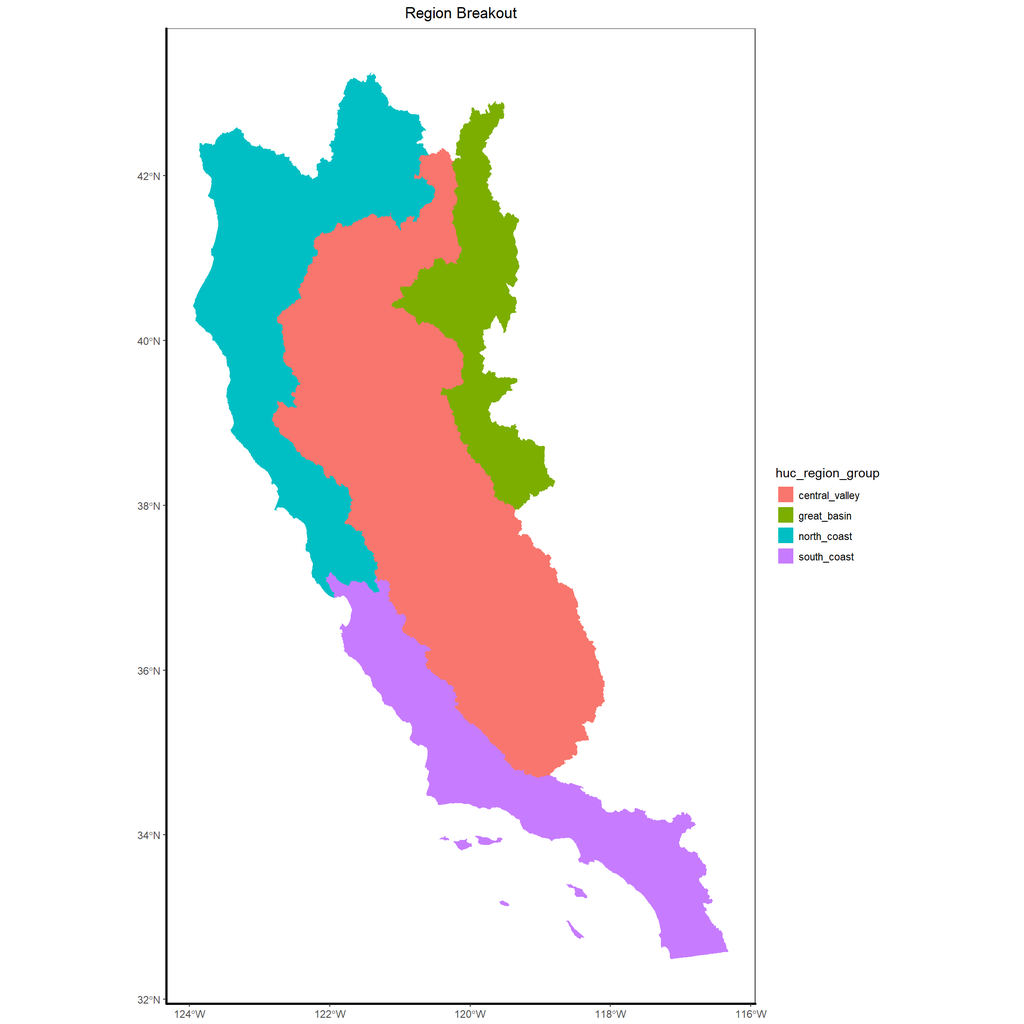

```r
writeLines("td, th { padding : 6px } th { background-color : #fff ; color : #000; border : 1px solid #333; } td { color : #000 ; border : 1px solid #333 }", con = "mystyle.css")  # add the CSS for the data tables

ggplot() +
  geom_sf(huc_data, lwd = 5, mapping=aes(fill=huc_region_group), color=NA)+
  ggtitle("Region Breakout") +
  theme_bw()+
  theme(panel.grid.major = element_line(colour = 'transparent'))+
  theme(strip.background = element_blank(), # facet theme control
        strip.placement = "outside",
        axis.line.x = element_line(color="black", size = 1),
        axis.line.y = element_line(color="black", size = 1),
        plot.title = element_text(hjust = 0.5))
```

## Central Valley

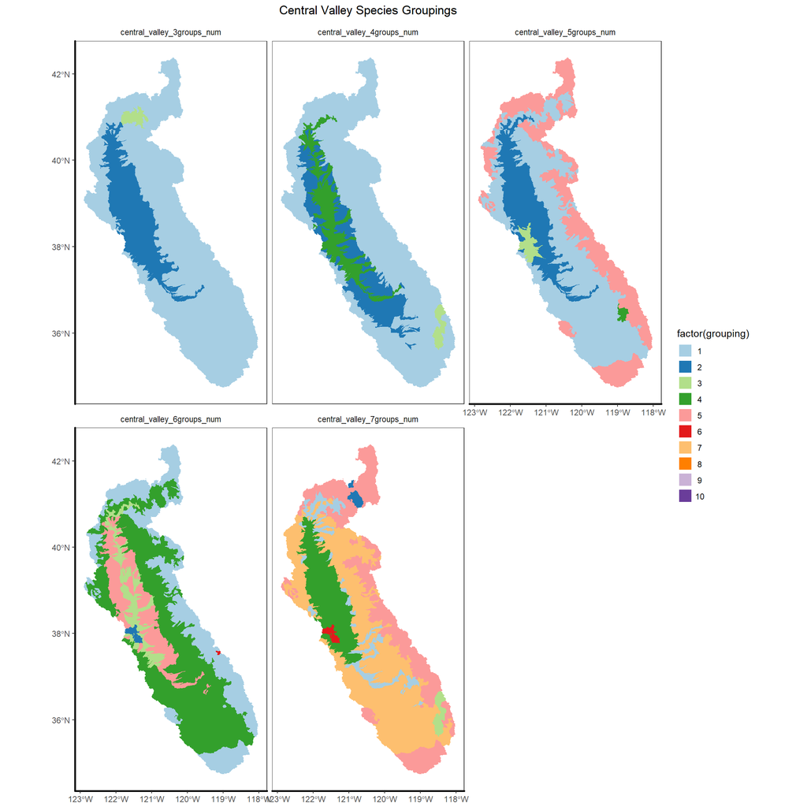

```r
cv_region_name = "central_valley"
cv_species_info <- species_maps(cv_region_name, "Central Valley", huc_data)
cv_species_info$region_map  # print the map
```

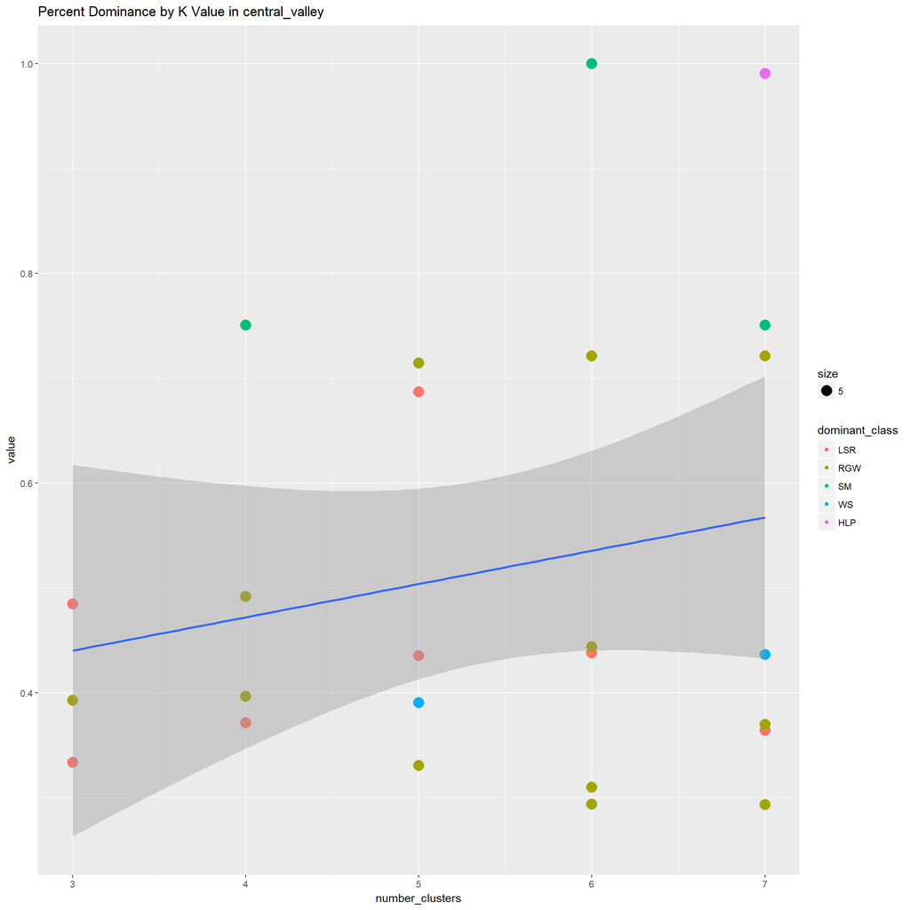

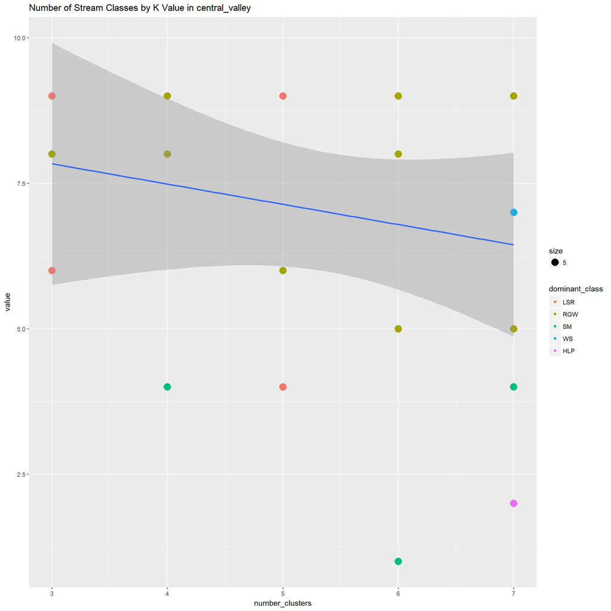

```r
print_dominance_plots(cv_species_info, cv_region_name)
```

```r
cv_species_lists <- species_lists_by_group_dfs(cv_species_info$species_data, cv_region_name)  # species_info$species_data is the data frame for the region
for(df in cv_species_lists){
  show(knitr::kable(df, format="html"))
}
```

| group_1 | group_2 | group_3 |
| --- | --- | --- |
| Pacific_lamprey | Pacific_lamprey | White_sturgeon |
| Kern_brook_lamprey | River_lamprey | California_roach |
| Western_brook_lamprey | Kern_brook_lamprey | Northern_roach |
| Southern_green_sturgeon | Western_brook_lamprey | Hardhead |
| White_sturgeon | Southern_green_sturgeon | Sacramento_pikeminnow |
| Owens_tui_chub | White_sturgeon | Sacramento_speckled_dace |
| Sacramento_hitch | Sacramento_hitch | Sacramento_sucker |
| California_roach | California_roach | Central_Valley_winter_Chinook_salmon |
| Red_Hills_roach | Sacramento_splittail | Central_Valley_spring_Chinook_salmon |
| Northern_roach | Hardhead | Central_Valley_late_fall_Chinook_salmon |
| Sacramento_splittail | Sacramento_pikeminnow | Central_Valley_fall_Chinook_salmon |
| Hardhead | Sacramento_speckled_dace | Bigeye_marbled_sculpin |
| Sacramento_pikeminnow | Sacramento_sucker | Pit_sculpin |
| Sacramento_speckled_dace | Longfin_smelt | Sacramento_tule_perch |
| Lahontan_mountain_sucker | Delta_smelt | NA |
| Sacramento_sucker | Central_Valley_winter_Chinook_salmon | NA |
| Modoc_sucker | Central_Valley_spring_Chinook_salmon | NA |
| Mountain_whitefish | Central_Valley_late_fall_Chinook_salmon | NA |
| Central_Valley_winter_Chinook_salmon | Central_Valley_fall_Chinook_salmon | NA |
| Central_Valley_spring_Chinook_salmon | Central_Coast_coho_salmon | NA |
| Central_Valley_late_fall_Chinook_salmon | Riffle_sculpin | NA |
| Central_Valley_fall_Chinook_salmon | Pit_sculpin | NA |
| Kern_River_rainbow_trout | Inland_threespine_stickleback | NA |
| Lahontan_cutthroat_trout | Sacramento_perch | NA |
| Riffle_sculpin | Sacramento_tule_perch | NA |
| Pit_sculpin | NA | NA |
| Inland_threespine_stickleback | NA | NA |
| Sacramento_perch | NA | NA |
| Sacramento_tule_perch | NA | NA |
| Kaweah_roach | NA | NA |

| group_1 | group_2 | group_3 | group_4 |
| --- | --- | --- | --- |
| Pacific_lamprey | Pacific_lamprey | Sacramento_hitch | Pacific_lamprey |
| Kern_brook_lamprey | River_lamprey | California_roach | River_lamprey |
| Western_brook_lamprey | Kern_brook_lamprey | Hardhead | Kern_brook_lamprey |
| Southern_green_sturgeon | Western_brook_lamprey | Sacramento_pikeminnow | Western_brook_lamprey |
| White_sturgeon | Southern_green_sturgeon | Sacramento_sucker | Southern_green_sturgeon |
| Owens_tui_chub | Sacramento_hitch | Kern_River_rainbow_trout | White_sturgeon |
| Sacramento_hitch | California_roach | Riffle_sculpin | Sacramento_hitch |
| California_roach | Sacramento_splittail | NA | California_roach |
| Red_Hills_roach | Hardhead | NA | Sacramento_splittail |
| Northern_roach | Sacramento_pikeminnow | NA | Hardhead |
| Sacramento_splittail | Sacramento_speckled_dace | NA | Sacramento_pikeminnow |
| Hardhead | Sacramento_sucker | NA | Sacramento_speckled_dace |
| Sacramento_pikeminnow | Delta_smelt | NA | Sacramento_sucker |
| Sacramento_speckled_dace | Central_Valley_spring_Chinook_salmon | NA | Longfin_smelt |
| Lahontan_mountain_sucker | Central_Valley_late_fall_Chinook_salmon | NA | Delta_smelt |
| Sacramento_sucker | Central_Valley_fall_Chinook_salmon | NA | Central_Valley_winter_Chinook_salmon |
| Modoc_sucker | Riffle_sculpin | NA | Central_Valley_spring_Chinook_salmon |
| Mountain_whitefish | Inland_threespine_stickleback | NA | Central_Valley_late_fall_Chinook_salmon |
| Central_Valley_winter_Chinook_salmon | Sacramento_perch | NA | Central_Valley_fall_Chinook_salmon |
| Central_Valley_spring_Chinook_salmon | Sacramento_tule_perch | NA | Central_Coast_coho_salmon |
| Central_Valley_late_fall_Chinook_salmon | NA | NA | Bigeye_marbled_sculpin |
| Central_Valley_fall_Chinook_salmon | NA | NA | Riffle_sculpin |
| Lahontan_cutthroat_trout | NA | NA | Pit_sculpin |
| Bigeye_marbled_sculpin | NA | NA | Inland_threespine_stickleback |
| Riffle_sculpin | NA | NA | Sacramento_perch |
| Pit_sculpin | NA | NA | Sacramento_tule_perch |
| Inland_threespine_stickleback | NA | NA | NA |
| Sacramento_perch | NA | NA | NA |
| Sacramento_tule_perch | NA | NA | NA |
| Kaweah_roach | NA | NA | NA |

| group_1 | group_2 | group_3 | group_4 | group_5 |
| --- | --- | --- | --- | --- |
| Pacific_lamprey | Pacific_lamprey | Pacific_lamprey | Hardhead | Pacific_lamprey |
| Kern_brook_lamprey | River_lamprey | River_lamprey | Sacramento_pikeminnow | Western_brook_lamprey |
| Western_brook_lamprey | Kern_brook_lamprey | Western_brook_lamprey | Sacramento_sucker | Owens_tui_chub |
| Southern_green_sturgeon | Western_brook_lamprey | Southern_green_sturgeon | Riffle_sculpin | Sacramento_hitch |
| White_sturgeon | Southern_green_sturgeon | White_sturgeon | Kaweah_roach | California_roach |
| Sacramento_hitch | White_sturgeon | Sacramento_hitch | NA | Northern_roach |
| California_roach | Sacramento_hitch | California_roach | NA | Sacramento_splittail |
| Red_Hills_roach | California_roach | Sacramento_splittail | NA | Hardhead |
| Northern_roach | Sacramento_splittail | Hardhead | NA | Sacramento_pikeminnow |
| Sacramento_splittail | Hardhead | Sacramento_pikeminnow | NA | Sacramento_speckled_dace |
| Hardhead | Sacramento_pikeminnow | Sacramento_speckled_dace | NA | Sacramento_sucker |
| Sacramento_pikeminnow | Sacramento_speckled_dace | Sacramento_sucker | NA | Modoc_sucker |
| Sacramento_speckled_dace | Sacramento_sucker | Longfin_smelt | NA | Mountain_whitefish |
| Lahontan_mountain_sucker | Delta_smelt | Delta_smelt | NA | Central_Valley_winter_Chinook_salmon |
| Sacramento_sucker | Central_Valley_winter_Chinook_salmon | Central_Valley_winter_Chinook_salmon | NA | Central_Valley_spring_Chinook_salmon |
| Modoc_sucker | Central_Valley_spring_Chinook_salmon | Central_Valley_spring_Chinook_salmon | NA | Central_Valley_late_fall_Chinook_salmon |
| Central_Valley_winter_Chinook_salmon | Central_Valley_late_fall_Chinook_salmon | Central_Valley_late_fall_Chinook_salmon | NA | Central_Valley_fall_Chinook_salmon |
| Central_Valley_spring_Chinook_salmon | Central_Valley_fall_Chinook_salmon | Central_Valley_fall_Chinook_salmon | NA | Kern_River_rainbow_trout |
| Central_Valley_late_fall_Chinook_salmon | Central_Coast_coho_salmon | Central_Coast_coho_salmon | NA | Lahontan_cutthroat_trout |
| Central_Valley_fall_Chinook_salmon | Bigeye_marbled_sculpin | Inland_threespine_stickleback | NA | Bigeye_marbled_sculpin |
| Kern_River_rainbow_trout | Riffle_sculpin | Sacramento_perch | NA | Riffle_sculpin |
| Bigeye_marbled_sculpin | Pit_sculpin | Sacramento_tule_perch | NA | Pit_sculpin |
| Riffle_sculpin | Inland_threespine_stickleback | NA | NA | Sacramento_perch |
| Pit_sculpin | Sacramento_perch | NA | NA | Sacramento_tule_perch |
| Inland_threespine_stickleback | Sacramento_tule_perch | NA | NA | NA |
| Sacramento_perch | NA | NA | NA | NA |
| Sacramento_tule_perch | NA | NA | NA | NA |

| group_1 | group_2 | group_3 | group_4 | group_5 | group_6 |
| --- | --- | --- | --- | --- | --- |
| Pacific_lamprey | Pacific_lamprey | Pacific_lamprey | Pacific_lamprey | Pacific_lamprey | Owens_tui_chub |
| Western_brook_lamprey | River_lamprey | River_lamprey | Kern_brook_lamprey | River_lamprey | NA |
| Sacramento_hitch | Western_brook_lamprey | Kern_brook_lamprey | Western_brook_lamprey | Kern_brook_lamprey | NA |
| California_roach | Southern_green_sturgeon | Western_brook_lamprey | Southern_green_sturgeon | Western_brook_lamprey | NA |
| Northern_roach | White_sturgeon | Southern_green_sturgeon | White_sturgeon | Southern_green_sturgeon | NA |
| Sacramento_splittail | Sacramento_hitch | White_sturgeon | Sacramento_hitch | Sacramento_hitch | NA |
| Hardhead | California_roach | Sacramento_hitch | California_roach | California_roach | NA |
| Sacramento_pikeminnow | Sacramento_splittail | California_roach | Red_Hills_roach | Sacramento_splittail | NA |
| Sacramento_speckled_dace | Hardhead | Sacramento_splittail | Northern_roach | Hardhead | NA |
| Sacramento_sucker | Sacramento_pikeminnow | Hardhead | Sacramento_splittail | Sacramento_pikeminnow | NA |
| Modoc_sucker | Sacramento_speckled_dace | Sacramento_pikeminnow | Hardhead | Sacramento_speckled_dace | NA |
| Mountain_whitefish | Sacramento_sucker | Sacramento_speckled_dace | Sacramento_pikeminnow | Sacramento_sucker | NA |
| Central_Valley_winter_Chinook_salmon | Longfin_smelt | Sacramento_sucker | Sacramento_speckled_dace | Delta_smelt | NA |
| Central_Valley_spring_Chinook_salmon | Delta_smelt | Delta_smelt | Lahontan_mountain_sucker | Central_Valley_winter_Chinook_salmon | NA |
| Central_Valley_late_fall_Chinook_salmon | Central_Valley_winter_Chinook_salmon | Central_Valley_winter_Chinook_salmon | Sacramento_sucker | Central_Valley_spring_Chinook_salmon | NA |
| Central_Valley_fall_Chinook_salmon | Central_Valley_spring_Chinook_salmon | Central_Valley_spring_Chinook_salmon | Modoc_sucker | Central_Valley_late_fall_Chinook_salmon | NA |
| Kern_River_rainbow_trout | Central_Valley_late_fall_Chinook_salmon | Central_Valley_late_fall_Chinook_salmon | Delta_smelt | Central_Valley_fall_Chinook_salmon | NA |
| Lahontan_cutthroat_trout | Central_Valley_fall_Chinook_salmon | Central_Valley_fall_Chinook_salmon | Central_Valley_winter_Chinook_salmon | Riffle_sculpin | NA |
| Bigeye_marbled_sculpin | Central_Coast_coho_salmon | Central_Coast_coho_salmon | Central_Valley_spring_Chinook_salmon | Inland_threespine_stickleback | NA |
| Riffle_sculpin | Inland_threespine_stickleback | Bigeye_marbled_sculpin | Central_Valley_late_fall_Chinook_salmon | Sacramento_perch | NA |
| Pit_sculpin | Sacramento_perch | Riffle_sculpin | Central_Valley_fall_Chinook_salmon | Sacramento_tule_perch | NA |
| Sacramento_perch | Sacramento_tule_perch | Pit_sculpin | Kern_River_rainbow_trout | NA | NA |
| Sacramento_tule_perch | NA | Inland_threespine_stickleback | Bigeye_marbled_sculpin | NA | NA |
| Kaweah_roach | NA | Sacramento_perch | Riffle_sculpin | NA | NA |
| NA | NA | Sacramento_tule_perch | Pit_sculpin | NA | NA |
| NA | NA | NA | Inland_threespine_stickleback | NA | NA |
| NA | NA | NA | Sacramento_perch | NA | NA |
| NA | NA | NA | Sacramento_tule_perch | NA | NA |
| NA | NA | NA | Kaweah_roach | NA | NA |

| group_1 | group_2 | group_3 | group_4 | group_5 | group_6 | group_7 |
| --- | --- | --- | --- | --- | --- | --- |
| Pacific_lamprey | Northern_roach | Sacramento_hitch | Pacific_lamprey | Western_brook_lamprey | Pacific_lamprey | Pacific_lamprey |
| Kern_brook_lamprey | Hardhead | California_roach | River_lamprey | Owens_tui_chub | River_lamprey | Kern_brook_lamprey |
| Western_brook_lamprey | Sacramento_pikeminnow | Hardhead | Western_brook_lamprey | Sacramento_hitch | Western_brook_lamprey | Western_brook_lamprey |
| White_sturgeon | Sacramento_speckled_dace | Sacramento_pikeminnow | Southern_green_sturgeon | California_roach | Southern_green_sturgeon | Southern_green_sturgeon |
| Sacramento_hitch | Sacramento_sucker | Sacramento_sucker | White_sturgeon | Northern_roach | White_sturgeon | White_sturgeon |
| California_roach | Modoc_sucker | Kern_River_rainbow_trout | Sacramento_hitch | Sacramento_splittail | Sacramento_hitch | Sacramento_hitch |
| Northern_roach | Pit_sculpin | Riffle_sculpin | California_roach | Hardhead | California_roach | California_roach |
| Sacramento_splittail | NA | NA | Sacramento_splittail | Sacramento_pikeminnow | Sacramento_splittail | Red_Hills_roach |
| Hardhead | NA | NA | Hardhead | Sacramento_speckled_dace | Hardhead | Sacramento_splittail |
| Sacramento_pikeminnow | NA | NA | Sacramento_pikeminnow | Sacramento_sucker | Sacramento_pikeminnow | Hardhead |
| Sacramento_speckled_dace | NA | NA | Sacramento_speckled_dace | Mountain_whitefish | Sacramento_speckled_dace | Sacramento_pikeminnow |
| Sacramento_sucker | NA | NA | Sacramento_sucker | Central_Valley_winter_Chinook_salmon | Sacramento_sucker | Sacramento_speckled_dace |
| Central_Valley_winter_Chinook_salmon | NA | NA | Delta_smelt | Central_Valley_spring_Chinook_salmon | Longfin_smelt | Lahontan_mountain_sucker |
| Central_Valley_spring_Chinook_salmon | NA | NA | Central_Valley_winter_Chinook_salmon | Lahontan_cutthroat_trout | Delta_smelt | Sacramento_sucker |
| Central_Valley_late_fall_Chinook_salmon | NA | NA | Central_Valley_spring_Chinook_salmon | Bigeye_marbled_sculpin | Central_Valley_winter_Chinook_salmon | Central_Valley_winter_Chinook_salmon |
| Central_Valley_fall_Chinook_salmon | NA | NA | Central_Valley_late_fall_Chinook_salmon | Riffle_sculpin | Central_Valley_spring_Chinook_salmon | Central_Valley_spring_Chinook_salmon |
| Central_Coast_coho_salmon | NA | NA | Central_Valley_fall_Chinook_salmon | Pit_sculpin | Central_Valley_late_fall_Chinook_salmon | Bigeye_marbled_sculpin |
| Bigeye_marbled_sculpin | NA | NA | Central_Coast_coho_salmon | Sacramento_perch | Central_Valley_fall_Chinook_salmon | Riffle_sculpin |
| Riffle_sculpin | NA | NA | Riffle_sculpin | Sacramento_tule_perch | Central_Coast_coho_salmon | Pit_sculpin |
| Pit_sculpin | NA | NA | Inland_threespine_stickleback | Kaweah_roach | Inland_threespine_stickleback | Inland_threespine_stickleback |
| Inland_threespine_stickleback | NA | NA | Sacramento_perch | NA | Sacramento_perch | Sacramento_perch |
| Sacramento_perch | NA | NA | Sacramento_tule_perch | NA | Sacramento_tule_perch | Sacramento_tule_perch |
| Sacramento_tule_perch | NA | NA | NA | NA | NA | Kaweah_roach |

## Great Basin

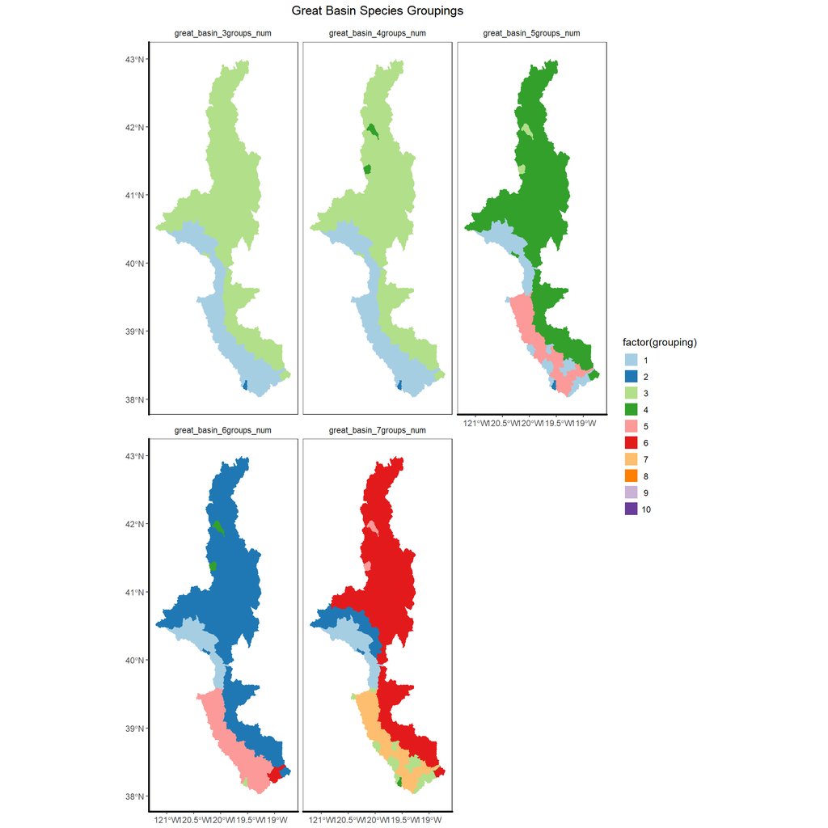

```r
gb_region_name <- "great_basin"
gb_species_info <- species_maps(gb_region_name, "Great Basin", huc_data)
gb_species_info$region_map  # print the map
```

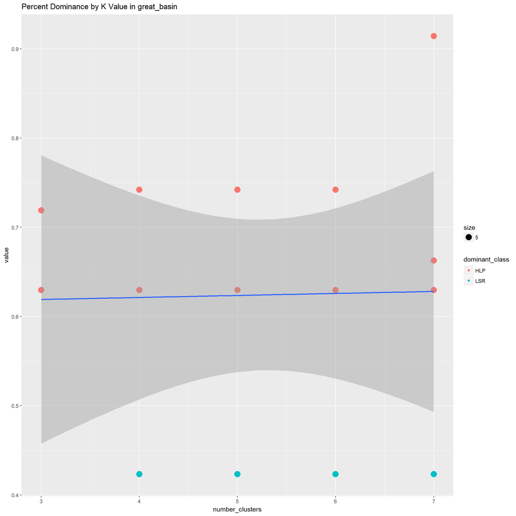

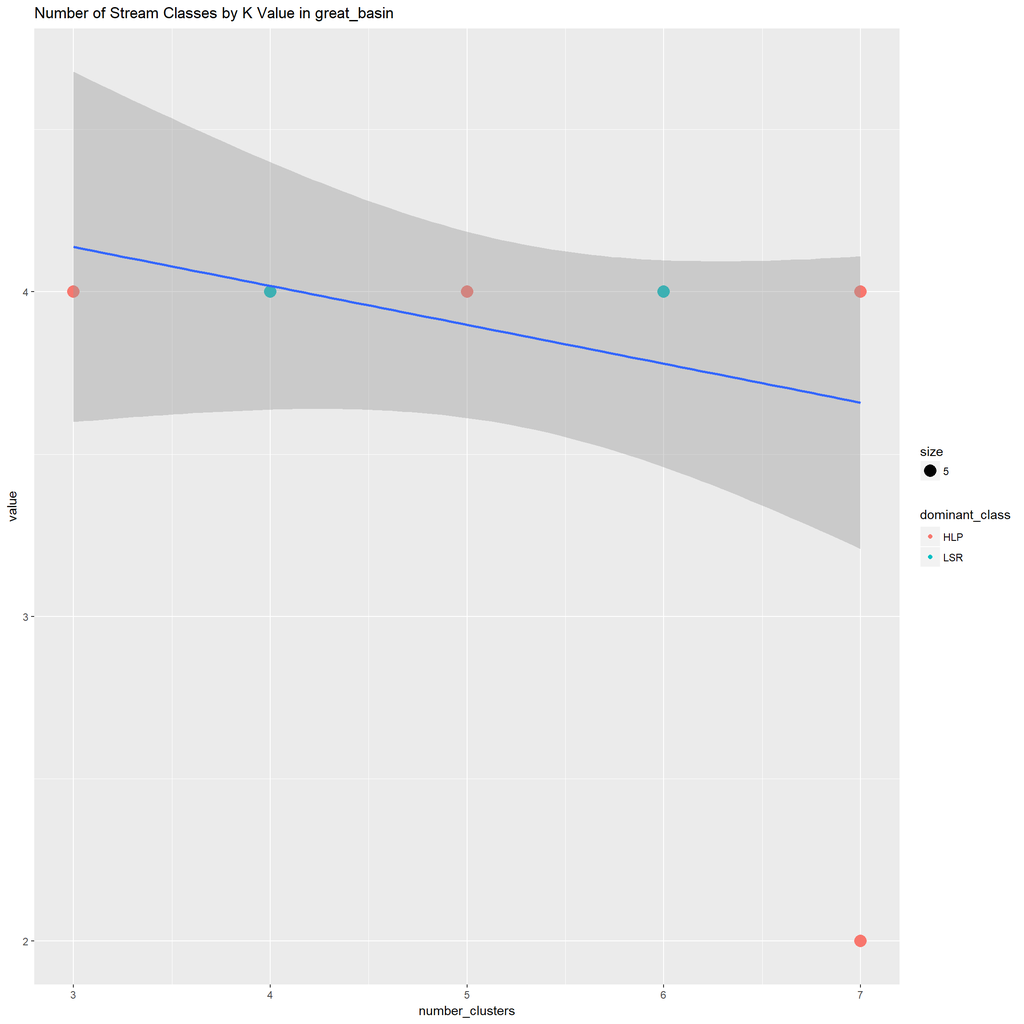

```r
print_dominance_plots(gb_species_info, gb_region_name)
```

```r
gb_species_lists <- species_lists_by_group_dfs(gb_species_info$species_data, gb_region_name)  # species_info$species_data is the data frame for the region
for(df in gb_species_lists){
  show(knitr::kable(df, format="html"))
}
```

| group_1 | group_2 | group_3 |
| --- | --- | --- |
| Lahontan_speckled_dace | California_roach | Sacramento_speckled_dace |
| Lahontan_mountain_sucker | Lahontan_speckled_dace | Lahontan_speckled_dace |
| Mountain_whitefish | Lahontan_mountain_sucker | NA |
| Lahontan_cutthroat_trout | Lahontan_cutthroat_trout | NA |

| group_1 | group_2 | group_3 | group_4 |
| --- | --- | --- | --- |
| Lahontan_speckled_dace | California_roach | Lahontan_speckled_dace | Sacramento_speckled_dace |
| Lahontan_mountain_sucker | Lahontan_speckled_dace | NA | NA |
| Mountain_whitefish | Lahontan_mountain_sucker | NA | NA |
| Lahontan_cutthroat_trout | Lahontan_cutthroat_trout | NA | NA |

| group_1 | group_2 | group_3 | group_4 | group_5 |
| --- | --- | --- | --- | --- |
| Lahontan_speckled_dace | California_roach | Sacramento_speckled_dace | Lahontan_speckled_dace | Lahontan_speckled_dace |
| Lahontan_mountain_sucker | Lahontan_speckled_dace | NA | NA | Lahontan_mountain_sucker |
| Lahontan_cutthroat_trout | Lahontan_mountain_sucker | NA | NA | Mountain_whitefish |
| NA | Lahontan_cutthroat_trout | NA | NA | Lahontan_cutthroat_trout |

| group_1 | group_2 | group_3 | group_4 | group_5 | group_6 |
| --- | --- | --- | --- | --- | --- |
| Lahontan_speckled_dace | Lahontan_speckled_dace | California_roach | Sacramento_speckled_dace | Lahontan_speckled_dace | Lahontan_speckled_dace |
| Lahontan_mountain_sucker | NA | Lahontan_speckled_dace | NA | Lahontan_mountain_sucker | Mountain_whitefish |
| NA | NA | Lahontan_mountain_sucker | NA | Mountain_whitefish | Lahontan_cutthroat_trout |
| NA | NA | Lahontan_cutthroat_trout | NA | Lahontan_cutthroat_trout | NA |

| group_1 | group_2 | group_3 | group_4 | group_5 | group_6 | group_7 |
| --- | --- | --- | --- | --- | --- | --- |
| Lahontan_speckled_dace | Lahontan_speckled_dace | Lahontan_speckled_dace | California_roach | Sacramento_speckled_dace | NA | Lahontan_speckled_dace |
| Lahontan_mountain_sucker | NA | Lahontan_mountain_sucker | Lahontan_speckled_dace | NA | NA | Lahontan_mountain_sucker |
| NA | NA | Lahontan_cutthroat_trout | Lahontan_mountain_sucker | NA | NA | Mountain_whitefish |
| NA | NA | NA | Lahontan_cutthroat_trout | NA | NA | Lahontan_cutthroat_trout |

## North Coast

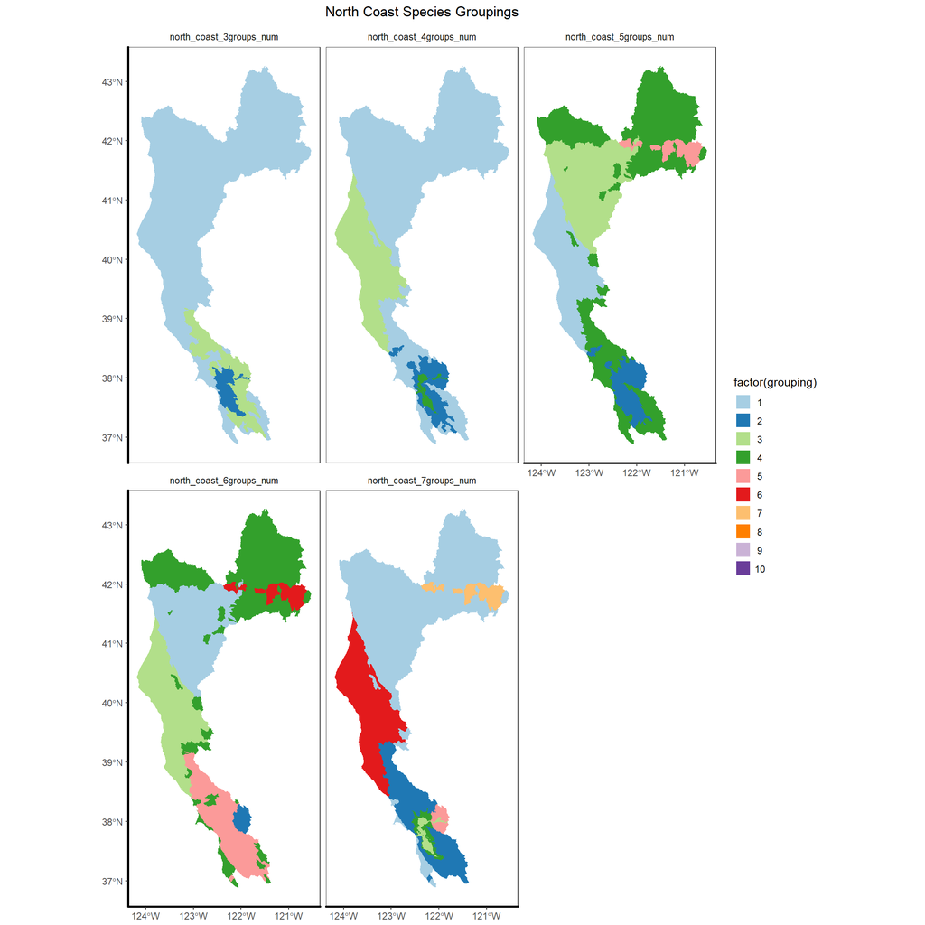

```r
coast_region_name = "north_coast"
coast_species_info <- species_maps(coast_region_name, "North Coast", huc_data)
coast_species_info$region_map  # print the map
```

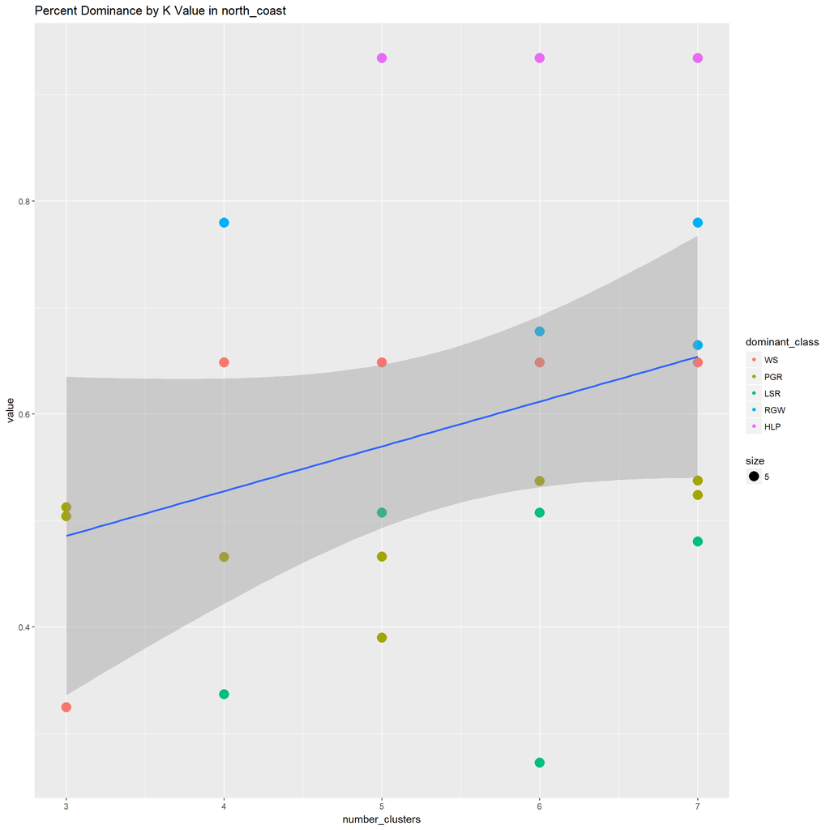

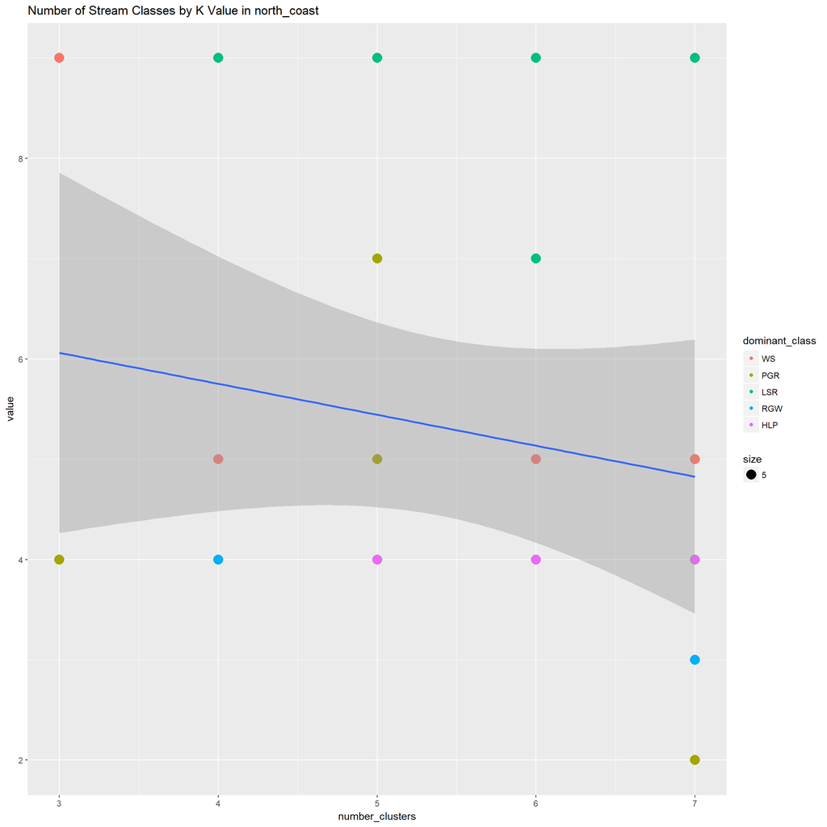

```r
print_dominance_plots(coast_species_info, coast_region_name)
```

```r
coast_species_lists <- species_lists_by_group_dfs(coast_species_info$species_data, coast_region_name)  # species_info$species_data is the data frame for the region
for(df in coast_species_lists){
  show(knitr::kable(df, format="html"))
}
```

| group_1 | group_2 | group_3 |
| --- | --- | --- |
| Pacific_lamprey | Pacific_lamprey | Pacific_lamprey |
| Klamath_River_lamprey | River_lamprey | River_lamprey |
| River_lamprey | Western_brook_lamprey | Western_brook_lamprey |
| Western_brook_lamprey | Southern_green_sturgeon | Southern_green_sturgeon |
| Northern_green_sturgeon | White_sturgeon | White_sturgeon |
| White_sturgeon | Sacramento_hitch | Sacramento_hitch |
| Blue_chub | California_roach | California_roach |
| Sacramento_hitch | Southern_coastal_roach | Southern_coastal_roach |
| Southern_coastal_roach | Sacramento_splittail | Sacramento_splittail |
| Hardhead | Hardhead | Hardhead |
| Sacramento_pikeminnow | Sacramento_pikeminnow | Sacramento_pikeminnow |
| Sacramento_sucker | Sacramento_speckled_dace | Sacramento_speckled_dace |
| Klamath_largescale_sucker | Sacramento_sucker | Sacramento_sucker |
| Lost_River_sucker | Longfin_smelt | Longfin_smelt |
| Shortnose_sucker | Delta_smelt | Delta_smelt |
| Longfin_smelt | Central_Valley_winter_Chinook_salmon | California_Coast_fall_Chinook_salmon |
| Upper_Klamath_Trinity_fall_Chinook_salmon | Central_Valley_spring_Chinook_salmon | Central_Coast_coho_salmon |
| Upper_Klamath_Trinity_spring_Chinook_salmon | Central_Valley_late_fall_Chinook_salmon | Central_California_coast_winter_steelhead |
| California_Coast_fall_Chinook_salmon | Central_Valley_fall_Chinook_salmon | Riffle_sculpin |
| Central_Coast_coho_salmon | Central_Coast_coho_salmon | Inland_threespine_stickleback |
| Southern_Oregon_Northern_California_coast_coho_salmon | Central_California_coast_winter_steelhead | Sacramento_perch |
| Northern_California_coast_winter_steelhead | Riffle_sculpin | Sacramento_tule_perch |
| Northern_California_coast_summer_steelhead | Inland_threespine_stickleback | NA |
| Klamath_Mountains_Province_winter_steelhead | Sacramento_perch | NA |
| Klamath_Mountains_Province_summer_steelhead | Sacramento_tule_perch | NA |
| Central_California_coast_winter_steelhead | Tidewater_goby | NA |
| Lower_Klamath_marbled_sculpin | NA | NA |
| Upper_Klamath_marbled_sculpin | NA | NA |
| Riffle_sculpin | NA | NA |
| Inland_threespine_stickleback | NA | NA |
| Sacramento_perch | NA | NA |
| Tidewater_goby | NA | NA |

| group_1 | group_2 | group_3 | group_4 |
| --- | --- | --- | --- |
| Pacific_lamprey | Pacific_lamprey | Pacific_lamprey | Pacific_lamprey |
| Klamath_River_lamprey | River_lamprey | River_lamprey | River_lamprey |
| River_lamprey | Western_brook_lamprey | Western_brook_lamprey | Western_brook_lamprey |
| Western_brook_lamprey | Southern_green_sturgeon | Northern_green_sturgeon | Southern_green_sturgeon |
| Northern_green_sturgeon | White_sturgeon | White_sturgeon | White_sturgeon |
| White_sturgeon | Sacramento_hitch | Sacramento_pikeminnow | Sacramento_hitch |
| Blue_chub | California_roach | Sacramento_sucker | California_roach |
| Sacramento_hitch | Southern_coastal_roach | Longfin_smelt | Sacramento_splittail |
| California_roach | Sacramento_splittail | California_Coast_fall_Chinook_salmon | Sacramento_speckled_dace |
| Southern_coastal_roach | Hardhead | Central_Coast_coho_salmon | Longfin_smelt |
| Hardhead | Sacramento_pikeminnow | Southern_Oregon_Northern_California_coast_coho_salmon | Delta_smelt |
| Sacramento_pikeminnow | Sacramento_speckled_dace | Northern_California_coast_winter_steelhead | Central_Valley_winter_Chinook_salmon |
| Sacramento_sucker | Sacramento_sucker | Northern_California_coast_summer_steelhead | Central_Valley_spring_Chinook_salmon |
| Klamath_largescale_sucker | Longfin_smelt | Inland_threespine_stickleback | Central_Valley_late_fall_Chinook_salmon |
| Lost_River_sucker | Delta_smelt | Tidewater_goby | Central_Valley_fall_Chinook_salmon |
| Shortnose_sucker | California_Coast_fall_Chinook_salmon | NA | Central_Coast_coho_salmon |
| Longfin_smelt | Central_Valley_spring_Chinook_salmon | NA | Central_California_coast_winter_steelhead |
| Upper_Klamath_Trinity_fall_Chinook_salmon | Central_Coast_coho_salmon | NA | Inland_threespine_stickleback |
| Upper_Klamath_Trinity_spring_Chinook_salmon | Central_California_coast_winter_steelhead | NA | Sacramento_tule_perch |
| California_Coast_fall_Chinook_salmon | Riffle_sculpin | NA | Tidewater_goby |
| Central_Coast_coho_salmon | Inland_threespine_stickleback | NA | NA |
| Southern_Oregon_Northern_California_coast_coho_salmon | Sacramento_perch | NA | NA |
| Northern_California_coast_summer_steelhead | Sacramento_tule_perch | NA | NA |
| Klamath_Mountains_Province_winter_steelhead | Tidewater_goby | NA | NA |
| Klamath_Mountains_Province_summer_steelhead | NA | NA | NA |
| Central_California_coast_winter_steelhead | NA | NA | NA |
| Lower_Klamath_marbled_sculpin | NA | NA | NA |
| Upper_Klamath_marbled_sculpin | NA | NA | NA |
| Riffle_sculpin | NA | NA | NA |
| Inland_threespine_stickleback | NA | NA | NA |
| Sacramento_perch | NA | NA | NA |
| Sacramento_tule_perch | NA | NA | NA |
| Tidewater_goby | NA | NA | NA |

| group_1 | group_2 | group_3 | group_4 | group_5 |
| --- | --- | --- | --- | --- |
| Pacific_lamprey | Pacific_lamprey | Pacific_lamprey | Pacific_lamprey | Pacific_lamprey |
| River_lamprey | River_lamprey | Klamath_River_lamprey | Klamath_River_lamprey | Klamath_River_lamprey |
| Western_brook_lamprey | Western_brook_lamprey | River_lamprey | River_lamprey | Blue_chub |
| Northern_green_sturgeon | Southern_green_sturgeon | Western_brook_lamprey | Western_brook_lamprey | Klamath_largescale_sucker |
| White_sturgeon | White_sturgeon | Northern_green_sturgeon | White_sturgeon | Lost_River_sucker |
| Sacramento_pikeminnow | Sacramento_hitch | White_sturgeon | Blue_chub | Shortnose_sucker |
| Sacramento_sucker | California_roach | Shortnose_sucker | Sacramento_hitch | Upper_Klamath_Trinity_fall_Chinook_salmon |
| Longfin_smelt | Southern_coastal_roach | Longfin_smelt | California_roach | Upper_Klamath_Trinity_spring_Chinook_salmon |
| California_Coast_fall_Chinook_salmon | Sacramento_splittail | Upper_Klamath_Trinity_fall_Chinook_salmon | Southern_coastal_roach | Southern_Oregon_Northern_California_coast_coho_salmon |
| Central_Coast_coho_salmon | Hardhead | Upper_Klamath_Trinity_spring_Chinook_salmon | Sacramento_splittail | Klamath_Mountains_Province_winter_steelhead |
| Southern_Oregon_Northern_California_coast_coho_salmon | Sacramento_pikeminnow | Southern_Oregon_Northern_California_coast_coho_salmon | Hardhead | Klamath_Mountains_Province_summer_steelhead |
| Northern_California_coast_winter_steelhead | Sacramento_speckled_dace | Klamath_Mountains_Province_winter_steelhead | Sacramento_pikeminnow | Upper_Klamath_marbled_sculpin |
| Northern_California_coast_summer_steelhead | Sacramento_sucker | Klamath_Mountains_Province_summer_steelhead | Sacramento_sucker | Sacramento_perch |
| Inland_threespine_stickleback | Longfin_smelt | Lower_Klamath_marbled_sculpin | Klamath_largescale_sucker | NA |
| Tidewater_goby | Delta_smelt | Inland_threespine_stickleback | Lost_River_sucker | NA |
| NA | California_Coast_fall_Chinook_salmon | Tidewater_goby | Shortnose_sucker | NA |
| NA | Central_Valley_winter_Chinook_salmon | NA | Upper_Klamath_Trinity_fall_Chinook_salmon | NA |
| NA | Central_Valley_spring_Chinook_salmon | NA | Upper_Klamath_Trinity_spring_Chinook_salmon | NA |
| NA | Central_Valley_late_fall_Chinook_salmon | NA | California_Coast_fall_Chinook_salmon | NA |
| NA | Central_Valley_fall_Chinook_salmon | NA | Central_Coast_coho_salmon | NA |
| NA | Central_Coast_coho_salmon | NA | Southern_Oregon_Northern_California_coast_coho_salmon | NA |
| NA | Central_California_coast_winter_steelhead | NA | Northern_California_coast_summer_steelhead | NA |
| NA | Riffle_sculpin | NA | Klamath_Mountains_Province_winter_steelhead | NA |
| NA | Inland_threespine_stickleback | NA | Central_California_coast_winter_steelhead | NA |
| NA | Sacramento_perch | NA | Riffle_sculpin | NA |
| NA | Sacramento_tule_perch | NA | Inland_threespine_stickleback | NA |
| NA | Tidewater_goby | NA | Sacramento_perch | NA |
| NA | NA | NA | Sacramento_tule_perch | NA |
| NA | NA | NA | Tidewater_goby | NA |

| group_1 | group_2 | group_3 | group_4 | group_5 | group_6 |
| --- | --- | --- | --- | --- | --- |
| Pacific_lamprey | Pacific_lamprey | Pacific_lamprey | Pacific_lamprey | Pacific_lamprey | Pacific_lamprey |
| Klamath_River_lamprey | River_lamprey | River_lamprey | Klamath_River_lamprey | River_lamprey | Klamath_River_lamprey |
| River_lamprey | Western_brook_lamprey | Western_brook_lamprey | River_lamprey | Western_brook_lamprey | Blue_chub |
| Western_brook_lamprey | Southern_green_sturgeon | Northern_green_sturgeon | Western_brook_lamprey | Southern_green_sturgeon | Klamath_largescale_sucker |
| Northern_green_sturgeon | White_sturgeon | White_sturgeon | Blue_chub | White_sturgeon | Lost_River_sucker |
| White_sturgeon | Sacramento_hitch | Sacramento_pikeminnow | Sacramento_hitch | Sacramento_hitch | Shortnose_sucker |
| Shortnose_sucker | California_roach | Sacramento_sucker | California_roach | California_roach | Upper_Klamath_Trinity_fall_Chinook_salmon |
| Longfin_smelt | Southern_coastal_roach | Longfin_smelt | Southern_coastal_roach | Southern_coastal_roach | Upper_Klamath_Trinity_spring_Chinook_salmon |
| Upper_Klamath_Trinity_fall_Chinook_salmon | Sacramento_splittail | California_Coast_fall_Chinook_salmon | Hardhead | Sacramento_splittail | Southern_Oregon_Northern_California_coast_coho_salmon |
| Upper_Klamath_Trinity_spring_Chinook_salmon | Hardhead | Central_Coast_coho_salmon | Sacramento_pikeminnow | Hardhead | Klamath_Mountains_Province_winter_steelhead |
| Southern_Oregon_Northern_California_coast_coho_salmon | Sacramento_pikeminnow | Southern_Oregon_Northern_California_coast_coho_salmon | Sacramento_sucker | Sacramento_pikeminnow | Klamath_Mountains_Province_summer_steelhead |
| Klamath_Mountains_Province_winter_steelhead | Sacramento_speckled_dace | Northern_California_coast_winter_steelhead | Klamath_largescale_sucker | Sacramento_sucker | Upper_Klamath_marbled_sculpin |
| Klamath_Mountains_Province_summer_steelhead | Sacramento_sucker | Northern_California_coast_summer_steelhead | Lost_River_sucker | Longfin_smelt | Sacramento_perch |
| Lower_Klamath_marbled_sculpin | Longfin_smelt | Inland_threespine_stickleback | Shortnose_sucker | Delta_smelt | NA |
| Inland_threespine_stickleback | Delta_smelt | Tidewater_goby | Upper_Klamath_Trinity_fall_Chinook_salmon | California_Coast_fall_Chinook_salmon | NA |
| Tidewater_goby | Central_Valley_winter_Chinook_salmon | NA | Upper_Klamath_Trinity_spring_Chinook_salmon | Central_Valley_winter_Chinook_salmon | NA |
| NA | Central_Valley_spring_Chinook_salmon | NA | California_Coast_fall_Chinook_salmon | Central_Valley_spring_Chinook_salmon | NA |
| NA | Central_Valley_late_fall_Chinook_salmon | NA | Central_Coast_coho_salmon | Central_Valley_late_fall_Chinook_salmon | NA |
| NA | Central_Valley_fall_Chinook_salmon | NA | Southern_Oregon_Northern_California_coast_coho_salmon | Central_Valley_fall_Chinook_salmon | NA |
| NA | Central_Coast_coho_salmon | NA | Northern_California_coast_summer_steelhead | Central_Coast_coho_salmon | NA |
| NA | Central_California_coast_winter_steelhead | NA | Klamath_Mountains_Province_winter_steelhead | Central_California_coast_winter_steelhead | NA |
| NA | Inland_threespine_stickleback | NA | Central_California_coast_winter_steelhead | Riffle_sculpin | NA |
| NA | Sacramento_tule_perch | NA | Riffle_sculpin | Inland_threespine_stickleback | NA |
| NA | NA | NA | Inland_threespine_stickleback | Sacramento_perch | NA |
| NA | NA | NA | Sacramento_perch | Sacramento_tule_perch | NA |
| NA | NA | NA | Tidewater_goby | Tidewater_goby | NA |

| group_1 | group_2 | group_3 | group_4 | group_5 | group_6 | group_7 |
| --- | --- | --- | --- | --- | --- | --- |
| Pacific_lamprey | Pacific_lamprey | Pacific_lamprey | Pacific_lamprey | Pacific_lamprey | Pacific_lamprey | Pacific_lamprey |
| Klamath_River_lamprey | River_lamprey | River_lamprey | River_lamprey | River_lamprey | River_lamprey | Klamath_River_lamprey |
| River_lamprey | Western_brook_lamprey | Western_brook_lamprey | Western_brook_lamprey | Western_brook_lamprey | Western_brook_lamprey | Blue_chub |
| Western_brook_lamprey | Southern_green_sturgeon | Southern_green_sturgeon | Southern_green_sturgeon | Southern_green_sturgeon | Northern_green_sturgeon | Klamath_largescale_sucker |
| Northern_green_sturgeon | White_sturgeon | White_sturgeon | White_sturgeon | White_sturgeon | White_sturgeon | Lost_River_sucker |
| White_sturgeon | Sacramento_hitch | Sacramento_hitch | Sacramento_hitch | Sacramento_hitch | Sacramento_pikeminnow | Shortnose_sucker |
| Blue_chub | California_roach | California_roach | Southern_coastal_roach | California_roach | Sacramento_sucker | Upper_Klamath_Trinity_fall_Chinook_salmon |
| Sacramento_pikeminnow | Southern_coastal_roach | Sacramento_splittail | Sacramento_splittail | Southern_coastal_roach | Longfin_smelt | Upper_Klamath_Trinity_spring_Chinook_salmon |
| Klamath_largescale_sucker | Sacramento_splittail | Sacramento_speckled_dace | Hardhead | Sacramento_splittail | California_Coast_fall_Chinook_salmon | Southern_Oregon_Northern_California_coast_coho_salmon |
| Lost_River_sucker | Hardhead | Longfin_smelt | Sacramento_pikeminnow | Hardhead | Central_Coast_coho_salmon | Klamath_Mountains_Province_winter_steelhead |
| Shortnose_sucker | Sacramento_pikeminnow | Delta_smelt | Sacramento_sucker | Sacramento_pikeminnow | Southern_Oregon_Northern_California_coast_coho_salmon | Klamath_Mountains_Province_summer_steelhead |
| Longfin_smelt | Sacramento_sucker | Central_Valley_winter_Chinook_salmon | Delta_smelt | Sacramento_speckled_dace | Northern_California_coast_winter_steelhead | Upper_Klamath_marbled_sculpin |
| Upper_Klamath_Trinity_fall_Chinook_salmon | Longfin_smelt | Central_Valley_spring_Chinook_salmon | Central_Valley_spring_Chinook_salmon | Sacramento_sucker | Northern_California_coast_summer_steelhead | Sacramento_perch |
| Upper_Klamath_Trinity_spring_Chinook_salmon | California_Coast_fall_Chinook_salmon | Central_Valley_late_fall_Chinook_salmon | Central_Coast_coho_salmon | Delta_smelt | Inland_threespine_stickleback | NA |
| California_Coast_fall_Chinook_salmon | Central_Coast_coho_salmon | Central_Valley_fall_Chinook_salmon | Central_California_coast_winter_steelhead | Central_California_coast_winter_steelhead | Tidewater_goby | NA |
| Central_Coast_coho_salmon | Central_California_coast_winter_steelhead | Central_Coast_coho_salmon | Riffle_sculpin | Inland_threespine_stickleback | NA | NA |
| Southern_Oregon_Northern_California_coast_coho_salmon | Riffle_sculpin | Central_California_coast_winter_steelhead | Sacramento_perch | Sacramento_tule_perch | NA | NA |
| Northern_California_coast_summer_steelhead | Inland_threespine_stickleback | Inland_threespine_stickleback | Sacramento_tule_perch | NA | NA | NA |
| Klamath_Mountains_Province_winter_steelhead | Sacramento_perch | Sacramento_tule_perch | Tidewater_goby | NA | NA | NA |
| Klamath_Mountains_Province_summer_steelhead | Sacramento_tule_perch | Tidewater_goby | NA | NA | NA | NA |
| Central_California_coast_winter_steelhead | Tidewater_goby | NA | NA | NA | NA | NA |
| Lower_Klamath_marbled_sculpin | NA | NA | NA | NA | NA | NA |
| Inland_threespine_stickleback | NA | NA | NA | NA | NA | NA |
| Sacramento_perch | NA | NA | NA | NA | NA | NA |
| Tidewater_goby | NA | NA | NA | NA | NA | NA |

## South Coast

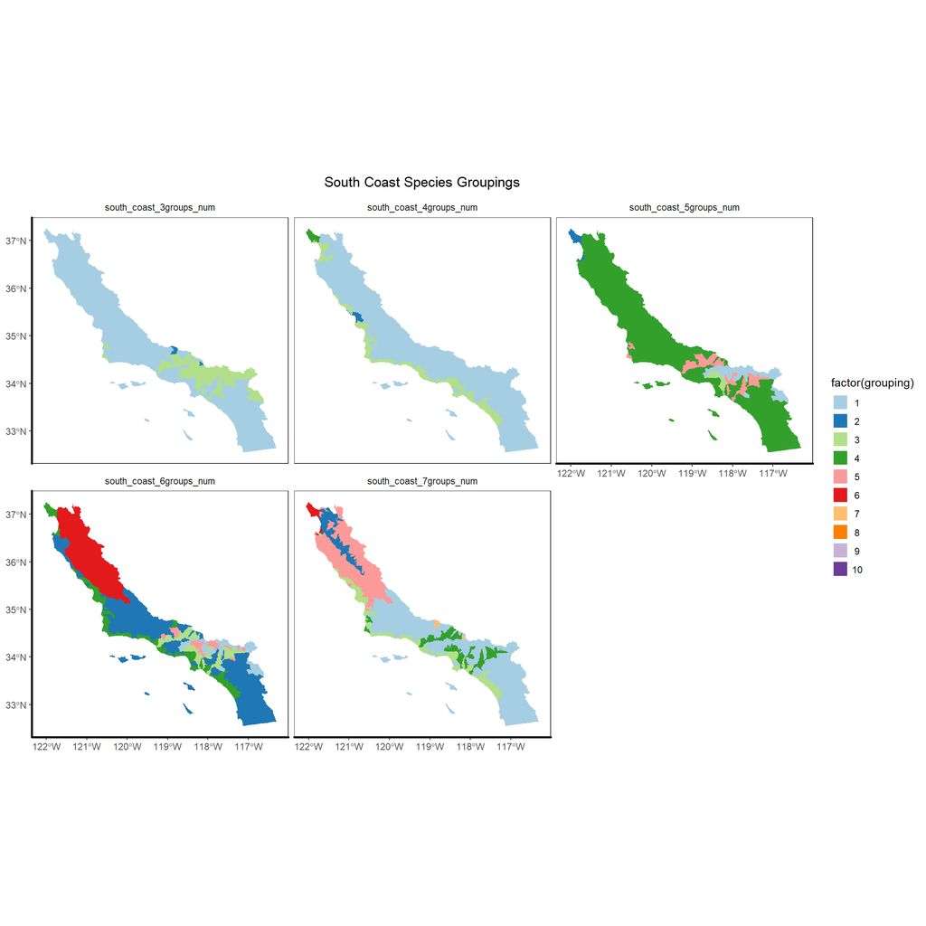

```r
soco_region_name = "south_coast"
soco_species_info <- species_maps(soco_region_name, "South Coast", huc_data)
soco_species_info$region_map  # print the map
```

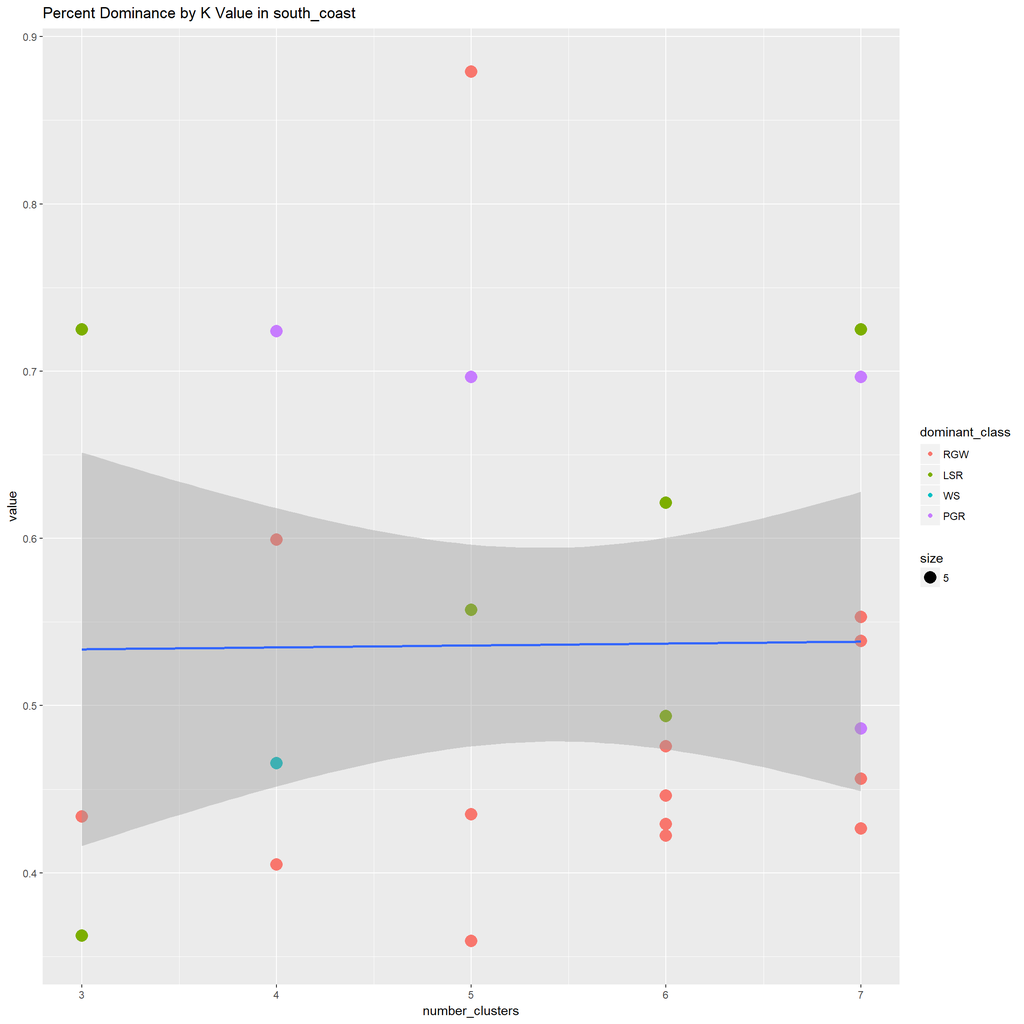

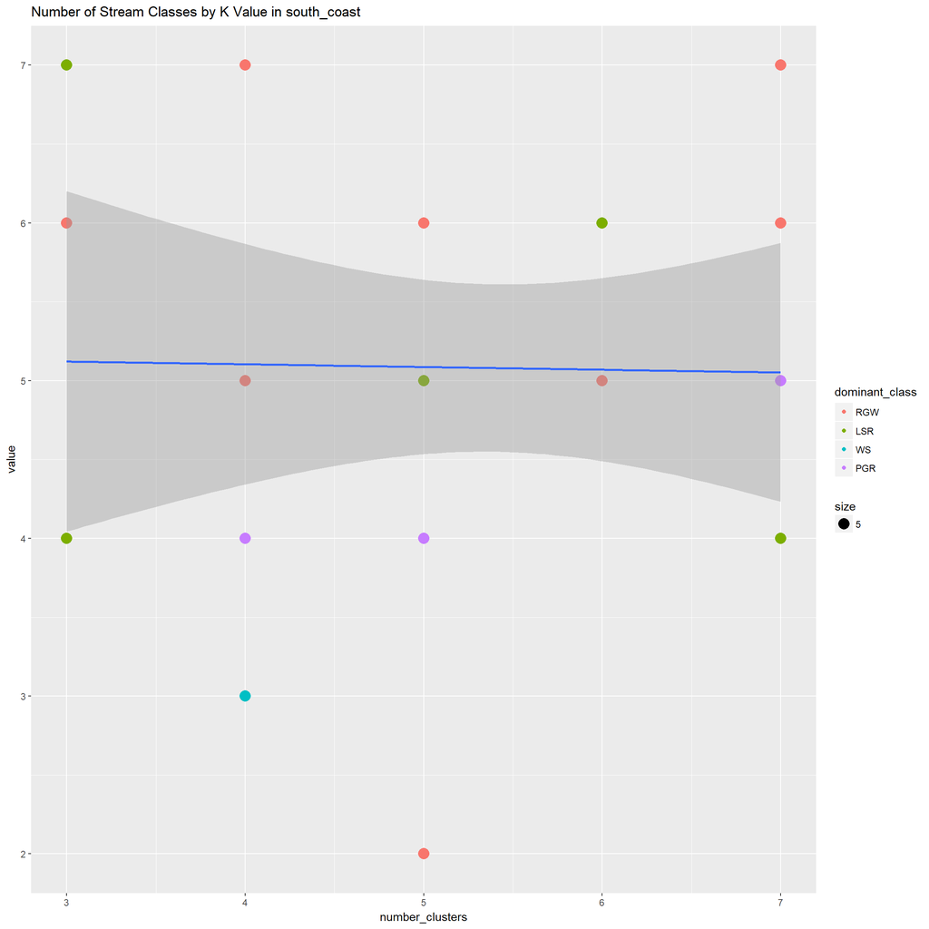

```r
print_dominance_plots(soco_species_info, soco_region_name)
```

```r
soco_species_lists <- species_lists_by_group_dfs(soco_species_info$species_data, soco_region_name)  # species_info$species_data is the data frame for the region
for(df in soco_species_lists){
  show(knitr::kable(df, format="html"))
}
```

| group_1 | group_2 | group_3 |
| --- | --- | --- |
| Pacific_lamprey | Pacific_lamprey | Pacific_lamprey |
| Arroyo_chub | Arroyo_chub | Western_brook_lamprey |
| Monterey_hitch | Sacramento_hitch | Arroyo_chub |
| California_roach | California_roach | Santa_Ana_speckled_dace |
| Southern_coastal_roach | Southern_California_steelhead | Santa_Ana_sucker |
| Sacramento_pikeminnow | Sacramento_tule_perch | Southern_California_steelhead |
| Sacramento_speckled_dace | NA | Inland_threespine_stickleback |
| Sacramento_sucker | NA | Unarmored_threespine_stickleback |
| Monterey_sucker | NA | Tidewater_goby |
| Central_Coast_coho_salmon | NA | NA |
| Central_California_coast_winter_steelhead | NA | NA |
| South_Central_California_coast_steelhead | NA | NA |
| Southern_California_steelhead | NA | NA |
| Riffle_sculpin | NA | NA |
| Inland_threespine_stickleback | NA | NA |
| Sacramento_perch | NA | NA |
| Sacramento_tule_perch | NA | NA |
| Tidewater_goby | NA | NA |

| group_1 | group_2 | group_3 | group_4 |
| --- | --- | --- | --- |
| Pacific_lamprey | Pacific_lamprey | Pacific_lamprey | Pacific_lamprey |
| Western_brook_lamprey | Arroyo_chub | Western_brook_lamprey | Southern_coastal_roach |
| Arroyo_chub | Sacramento_pikeminnow | Arroyo_chub | Sacramento_speckled_dace |
| Sacramento_hitch | Sacramento_sucker | Monterey_hitch | Central_Coast_coho_salmon |
| Monterey_hitch | South_Central_California_coast_steelhead | Southern_coastal_roach | Central_California_coast_winter_steelhead |
| California_roach | Inland_threespine_stickleback | Sacramento_pikeminnow | Inland_threespine_stickleback |
| Southern_coastal_roach | Tidewater_goby | Sacramento_speckled_dace | Tidewater_goby |
| Sacramento_pikeminnow | NA | Monterey_sucker | NA |
| Sacramento_speckled_dace | NA | Santa_Ana_sucker | NA |
| Santa_Ana_speckled_dace | NA | Central_Coast_coho_salmon | NA |
| Monterey_sucker | NA | South_Central_California_coast_steelhead | NA |
| Santa_Ana_sucker | NA | Southern_California_steelhead | NA |
| South_Central_California_coast_steelhead | NA | Riffle_sculpin | NA |
| Southern_California_steelhead | NA | Inland_threespine_stickleback | NA |
| Riffle_sculpin | NA | Unarmored_threespine_stickleback | NA |
| Inland_threespine_stickleback | NA | Sacramento_perch | NA |
| Unarmored_threespine_stickleback | NA | Sacramento_tule_perch | NA |
| Sacramento_perch | NA | Tidewater_goby | NA |
| Sacramento_tule_perch | NA | NA | NA |

| group_1 | group_2 | group_3 | group_4 | group_5 |
| --- | --- | --- | --- | --- |
| Arroyo_chub | Pacific_lamprey | Pacific_lamprey | Pacific_lamprey | Pacific_lamprey |
| Santa_Ana_speckled_dace | Southern_coastal_roach | Western_brook_lamprey | Arroyo_chub | Arroyo_chub |
| Santa_Ana_sucker | Sacramento_speckled_dace | Arroyo_chub | Sacramento_hitch | Santa_Ana_speckled_dace |
| Southern_California_steelhead | Central_Coast_coho_salmon | Santa_Ana_speckled_dace | Monterey_hitch | Santa_Ana_sucker |
| Inland_threespine_stickleback | Central_California_coast_winter_steelhead | Santa_Ana_sucker | California_roach | Southern_California_steelhead |
| NA | South_Central_California_coast_steelhead | Southern_California_steelhead | Southern_coastal_roach | Inland_threespine_stickleback |
| NA | Inland_threespine_stickleback | Inland_threespine_stickleback | Sacramento_pikeminnow | Unarmored_threespine_stickleback |
| NA | Tidewater_goby | Unarmored_threespine_stickleback | Sacramento_speckled_dace | Tidewater_goby |
| NA | NA | Tidewater_goby | Sacramento_sucker | NA |
| NA | NA | NA | Monterey_sucker | NA |
| NA | NA | NA | South_Central_California_coast_steelhead | NA |
| NA | NA | NA | Southern_California_steelhead | NA |
| NA | NA | NA | Riffle_sculpin | NA |
| NA | NA | NA | Inland_threespine_stickleback | NA |
| NA | NA | NA | Sacramento_perch | NA |
| NA | NA | NA | Sacramento_tule_perch | NA |
| NA | NA | NA | Tidewater_goby | NA |

| group_1 | group_2 | group_3 | group_4 | group_5 | group_6 |
| --- | --- | --- | --- | --- | --- |
| Arroyo_chub | Pacific_lamprey | Pacific_lamprey | Pacific_lamprey | Pacific_lamprey | Pacific_lamprey |
| Santa_Ana_speckled_dace | Arroyo_chub | Western_brook_lamprey | Arroyo_chub | Arroyo_chub | Monterey_hitch |
| Southern_California_steelhead | Sacramento_hitch | Arroyo_chub | Sacramento_hitch | Santa_Ana_speckled_dace | California_roach |
| Inland_threespine_stickleback | California_roach | Santa_Ana_speckled_dace | California_roach | Santa_Ana_sucker | Southern_coastal_roach |
| NA | Sacramento_speckled_dace | Santa_Ana_sucker | Southern_coastal_roach | Southern_California_steelhead | Sacramento_pikeminnow |
| NA | South_Central_California_coast_steelhead | Southern_California_steelhead | Sacramento_pikeminnow | NA | Sacramento_speckled_dace |
| NA | Southern_California_steelhead | Inland_threespine_stickleback | Sacramento_speckled_dace | NA | Monterey_sucker |
| NA | Inland_threespine_stickleback | Unarmored_threespine_stickleback | Sacramento_sucker | NA | South_Central_California_coast_steelhead |
| NA | NA | Tidewater_goby | Central_Coast_coho_salmon | NA | Riffle_sculpin |
| NA | NA | NA | Central_California_coast_winter_steelhead | NA | Inland_threespine_stickleback |
| NA | NA | NA | South_Central_California_coast_steelhead | NA | Sacramento_perch |
| NA | NA | NA | Southern_California_steelhead | NA | Sacramento_tule_perch |
| NA | NA | NA | Inland_threespine_stickleback | NA | Tidewater_goby |
| NA | NA | NA | Unarmored_threespine_stickleback | NA | NA |
| NA | NA | NA | Sacramento_tule_perch | NA | NA |
| NA | NA | NA | Tidewater_goby | NA | NA |

| group_1 | group_2 | group_3 | group_4 | group_5 | group_6 | group_7 |
| --- | --- | --- | --- | --- | --- | --- |
| Pacific_lamprey | Pacific_lamprey | Pacific_lamprey | Pacific_lamprey | Pacific_lamprey | Pacific_lamprey | Pacific_lamprey |
| Arroyo_chub | Monterey_hitch | Arroyo_chub | Western_brook_lamprey | Monterey_hitch | Southern_coastal_roach | Arroyo_chub |
| California_roach | Southern_coastal_roach | Sacramento_pikeminnow | Arroyo_chub | California_roach | Sacramento_speckled_dace | Sacramento_hitch |
| Sacramento_speckled_dace | Sacramento_pikeminnow | Sacramento_speckled_dace | Santa_Ana_speckled_dace | Southern_coastal_roach | Central_Coast_coho_salmon | California_roach |
| Santa_Ana_speckled_dace | Sacramento_speckled_dace | Sacramento_sucker | Santa_Ana_sucker | Sacramento_pikeminnow | Central_California_coast_winter_steelhead | Southern_California_steelhead |
| Santa_Ana_sucker | Monterey_sucker | South_Central_California_coast_steelhead | Southern_California_steelhead | Sacramento_speckled_dace | South_Central_California_coast_steelhead | Sacramento_tule_perch |
| Southern_California_steelhead | South_Central_California_coast_steelhead | Southern_California_steelhead | Inland_threespine_stickleback | Monterey_sucker | Inland_threespine_stickleback | NA |
| Inland_threespine_stickleback | Riffle_sculpin | Inland_threespine_stickleback | Unarmored_threespine_stickleback | South_Central_California_coast_steelhead | Tidewater_goby | NA |
| NA | Inland_threespine_stickleback | Sacramento_tule_perch | Tidewater_goby | Riffle_sculpin | NA | NA |
| NA | Sacramento_perch | Tidewater_goby | NA | Inland_threespine_stickleback | NA | NA |
| NA | Sacramento_tule_perch | NA | NA | Sacramento_perch | NA | NA |
| NA | Tidewater_goby | NA | NA | Sacramento_tule_perch | NA | NA |